# Description

## Background and Context

Data Analysis for "Visit with us" company to enable and establish a viable business model to expand the customer base. A viable business model is a central concept that helps us understand the existing ways of doing the business and how to change the ways for the benefit of the tourism sector.

One of the ways to expand the customer base is to introduce a new offering of packages.

Currently, there are 5 types of packages the company is offering - Basic, Standard, Deluxe, Super Deluxe, King. Looking at the data of the last year, we observed that 18% of the customers purchased the packages.

The company in the last campaign contacted the customers at random without looking at the available information. However, this time company is now planning to launch a new product i.e. Wellness Tourism Package. Wellness Tourism is defined as Travel that allows the traveler to maintain, enhance or kick-start a healthy lifestyle, and support or increase one's sense of well-being, and wants to harness the available data of existing and potential customers to make the marketing expenditure more efficient.

As a Data Scientist at the "Visit with us" travel firm, a study is done on consumer data and information in order to make recommendations to the Policy Maker and Marketing Team, as well as develop a model to anticipate who will buy the newly launched vacation package.

## Objective

To predict which customer is more likely to purchase the newly introduced travel package.

## Data Dictionary

Customer details:

- CustomerID: Unique customer ID
- ProdTaken: Whether the customer has purchased a package or not (0: No, 1: Yes)
- Age: Age of customer
- TypeofContact: How customer was contacted (Company Invited or Self Inquiry)
- CityTier: City tier depends on the development of a city, population, facilities, and living standards. The categories are ordered i.e. Tier 1 > Tier 2 > Tier 3
- Occupation: Occupation of customer
- Gender: Gender of customer
- NumberOfPersonVisiting: Total number of persons planning to take the trip with the customer
- PreferredPropertyStar: Preferred hotel property rating by customer
- MaritalStatus: Marital status of customer
- NumberOfTrips: Average number of trips in a year by customer
- Passport: The customer has a passport or not (0: No, 1: Yes)
- OwnCar: Whether the customers own a car or not (0: No, 1: Yes)
- NumberOfChildrenVisiting: Total number of children with age less than 5 planning to take the trip with the customer
- Designation: Designation of the customer in the current organization
- MonthlyIncome: Gross monthly income of the customer

## Customer interaction data:

PitchSatisfactionScore: Sales pitch satisfaction score  
ProductPitched: Product pitched by the salesperson  
NumberOfFollowups: Total number of follow-ups has been done by the salesperson after the sales pitch  
DurationOfPitch: Duration of the pitch by a salesperson to the customer

## Importing and installing Libraries

```python
!pip install xgboost
!pip install xlrd
!pip install openpyxl

import scipy.stats as stats
import pandas as pd
import numpy as np

import matplotlib.pyplot as plt
%matplotlib inline
import seaborn as sns
import warnings

import statsmodels.api as sm

#--Sklearn library--
from sklearn.model_selection import train_test_split

from sklearn import metrics

from sklearn.ensemble import BaggingClassifier,RandomForestClassifier,StackingClassifier
from sklearn.tree import DecisionTreeClassifier
from sklearn.ensemble import AdaBoostClassifier, GradientBoostingClassifier

from xgboost import XGBClassifier
from sklearn import tree
from sklearn.linear_model import LogisticRegression

# Library to tune model
from sklearn.metrics import  classification_report, accuracy_score, precision_score, recall_score,f1_score
from sklearn.model_selection import GridSearchCV
from sklearn.metrics import confusion_matrix,ConfusionMatrixDisplay,plot_confusion_matrix

pd.set_option('display.float_format', lambda x: '%.3f' % x)
pd.set_option('display.max_rows', 300)
pd.set_option('display.max_colwidth',400)

pd.set_option('display.float_format', lambda x: '%.5f' % x)
warnings.filterwarnings('ignore')

plt.style.use('ggplot')
```

## Data

```python
df=pd.read_csv("Tourism.csv")

data=df.copy()
print(f'There are {data.shape[0]} rows and {data.shape[1]} columns')
```

```
There are 4888 rows and 20 columns
```

```python
data.head()
```

|  | CustomerID | ProdTaken | Age | TypeofContact | CityTier | DurationOfPitch | Occupation | Gender | NumberOfPersonVisiting | NumberOfFollowups | ProductPitched | PreferredPropertyStar | MaritalStatus | NumberOfTrips | Passport | PitchSatisfactionScore | OwnCar | NumberOfChildrenVisiting | Designation | MonthlyIncome |
| --- | --- | --- | --- | --- | --- | --- | --- | --- | --- | --- | --- | --- | --- | --- | --- | --- | --- | --- | --- | --- |
| 0 | 200000 | 1 | 41.00000 | Self Enquiry | 3 | 6.00000 | Salaried | Female | 3 | 3.00000 | Deluxe | 3.00000 | Single | 1.00000 | 1 | 2 | 1 | 0.00000 | Manager | 20993.00000 |
| 1 | 200001 | 0 | 49.00000 | Company Invited | 1 | 14.00000 | Salaried | Male | 3 | 4.00000 | Deluxe | 4.00000 | Divorced | 2.00000 | 0 | 3 | 1 | 2.00000 | Manager | 20130.00000 |
| 2 | 200002 | 1 | 37.00000 | Self Enquiry | 1 | 8.00000 | Free Lancer | Male | 3 | 4.00000 | Basic | 3.00000 | Single | 7.00000 | 1 | 3 | 0 | 0.00000 | Executive | 17090.00000 |
| 3 | 200003 | 0 | 33.00000 | Company Invited | 1 | 9.00000 | Salaried | Female | 2 | 3.00000 | Basic | 3.00000 | Divorced | 2.00000 | 1 | 5 | 1 | 1.00000 | Executive | 17909.00000 |
| 4 | 200004 | 0 | nan | Self Enquiry | 1 | 8.00000 | Small Business | Male | 2 | 3.00000 | Basic | 4.00000 | Divorced | 1.00000 | 0 | 5 | 1 | 0.00000 | Executive | 18468.00000 |

```python
data.tail()
```

|  | CustomerID | ProdTaken | Age | TypeofContact | CityTier | DurationOfPitch | Occupation | Gender | NumberOfPersonVisiting | NumberOfFollowups | ProductPitched | PreferredPropertyStar | MaritalStatus | NumberOfTrips | Passport | PitchSatisfactionScore | OwnCar | NumberOfChildrenVisiting | Designation | MonthlyIncome |
| --- | --- | --- | --- | --- | --- | --- | --- | --- | --- | --- | --- | --- | --- | --- | --- | --- | --- | --- | --- | --- |
| 4883 | 204883 | 1 | 49.00000 | Self Enquiry | 3 | 9.00000 | Small Business | Male | 3 | 5.00000 | Deluxe | 4.00000 | Unmarried | 2.00000 | 1 | 1 | 1 | 1.00000 | Manager | 26576.00000 |
| 4884 | 204884 | 1 | 28.00000 | Company Invited | 1 | 31.00000 | Salaried | Male | 4 | 5.00000 | Basic | 3.00000 | Single | 3.00000 | 1 | 3 | 1 | 2.00000 | Executive | 21212.00000 |
| 4885 | 204885 | 1 | 52.00000 | Self Enquiry | 3 | 17.00000 | Salaried | Female | 4 | 4.00000 | Standard | 4.00000 | Married | 7.00000 | 0 | 1 | 1 | 3.00000 | Senior Manager | 31820.00000 |
| 4886 | 204886 | 1 | 19.00000 | Self Enquiry | 3 | 16.00000 | Small Business | Male | 3 | 4.00000 | Basic | 3.00000 | Single | 3.00000 | 0 | 5 | 0 | 2.00000 | Executive | 20289.00000 |
| 4887 | 204887 | 1 | 36.00000 | Self Enquiry | 1 | 14.00000 | Salaried | Male | 4 | 4.00000 | Basic | 4.00000 | Unmarried | 3.00000 | 1 | 3 | 1 | 2.00000 | Executive | 24041.00000 |

```python
print ("Columns : \n\n", data.columns.tolist())
print ("*"*120,"\nMissing values :\n\n", data.isnull().sum().sort_values(ascending=False))
print( "*"*120,"\nPercentage of missing :\n\n", round(data.isna().sum() / data.isna().count() * 100, 2).sort_values(ascending=False))
```

[output not shown]

```python
data.info()
```

```
<class 'pandas.core.frame.DataFrame'>
RangeIndex: 4888 entries, 0 to 4887
Data columns (total 20 columns):
 #   Column                    Non-Null Count  Dtype
---  ------                    --------------  -----
 0   CustomerID                4888 non-null   int64
 1   ProdTaken                 4888 non-null   int64
 2   Age                       4662 non-null   float64
 3   TypeofContact             4863 non-null   object
 4   CityTier                  4888 non-null   int64
 5   DurationOfPitch           4637 non-null   float64
 6   Occupation                4888 non-null   object
 7   Gender                    4888 non-null   object
 8   NumberOfPersonVisiting    4888 non-null   int64
 9   NumberOfFollowups         4843 non-null   float64
 10  ProductPitched            4888 non-null   object
 11  PreferredPropertyStar     4862 non-null   float64
 12  MaritalStatus             4888 non-null   object
 13  NumberOfTrips             4748 non-null   float64
 14  Passport                  4888 non-null   int64
 15  PitchSatisfactionScore    4888 non-null   int64
 16  OwnCar                    4888 non-null   int64
 17  NumberOfChildrenVisiting  4822 non-null   float64
 18  Designation               4888 non-null   object
 19  MonthlyIncome             4655 non-null   float64
dtypes: float64(7), int64(7), object(6)
memory usage: 763.9+ KB
```

```python
data.describe().T
```

|  | count | mean | std | min | 25% | 50% | 75% | max |
| --- | --- | --- | --- | --- | --- | --- | --- | --- |
| CustomerID | 4888.00000 | 202443.50000 | 1411.18839 | 200000.00000 | 201221.75000 | 202443.50000 | 203665.25000 | 204887.00000 |
| ProdTaken | 4888.00000 | 0.18822 | 0.39092 | 0.00000 | 0.00000 | 0.00000 | 0.00000 | 1.00000 |
| Age | 4662.00000 | 37.62227 | 9.31639 | 18.00000 | 31.00000 | 36.00000 | 44.00000 | 61.00000 |
| CityTier | 4888.00000 | 1.65426 | 0.91658 | 1.00000 | 1.00000 | 1.00000 | 3.00000 | 3.00000 |
| DurationOfPitch | 4637.00000 | 15.49083 | 8.51964 | 5.00000 | 9.00000 | 13.00000 | 20.00000 | 127.00000 |
| NumberOfPersonVisiting | 4888.00000 | 2.90507 | 0.72489 | 1.00000 | 2.00000 | 3.00000 | 3.00000 | 5.00000 |
| NumberOfFollowups | 4843.00000 | 3.70845 | 1.00251 | 1.00000 | 3.00000 | 4.00000 | 4.00000 | 6.00000 |
| PreferredPropertyStar | 4862.00000 | 3.58104 | 0.79801 | 3.00000 | 3.00000 | 3.00000 | 4.00000 | 5.00000 |
| NumberOfTrips | 4748.00000 | 3.23652 | 1.84902 | 1.00000 | 2.00000 | 3.00000 | 4.00000 | 22.00000 |
| Passport | 4888.00000 | 0.29092 | 0.45423 | 0.00000 | 0.00000 | 0.00000 | 1.00000 | 1.00000 |
| PitchSatisfactionScore | 4888.00000 | 3.07815 | 1.36579 | 1.00000 | 2.00000 | 3.00000 | 4.00000 | 5.00000 |
| OwnCar | 4888.00000 | 0.62029 | 0.48536 | 0.00000 | 0.00000 | 1.00000 | 1.00000 | 1.00000 |
| NumberOfChildrenVisiting | 4822.00000 | 1.18727 | 0.85786 | 0.00000 | 1.00000 | 1.00000 | 2.00000 | 3.00000 |
| MonthlyIncome | 4655.00000 | 23619.85349 | 5380.69836 | 1000.00000 | 20346.00000 | 22347.00000 | 25571.00000 | 98678.00000 |

### Inference

- The features of the dataset are: *'CustomerID', 'ProdTaken', 'Age', 'TypeofContact', 'CityTier', 'DurationOfPitch', 'Occupation', 'Gender', 'NumberOfPersonVisiting', 'NumberOfFollowups', 'ProductPitched', 'PreferredPropertyStar', 'MaritalStatus', 'NumberOfTrips', 'Passport', 'PitchSatisfactionScore', 'OwnCar', 'NumberOfChildrenVisiting', 'Designation', 'MonthlyIncome'
- We can drop the customer ID column
- The proportion of **missing values** is less. DurationOfPitch has 251 missing values that is 5% of values MonthlyIncome has 233 missing values that is 4.77% of values Age has 226 missing values that is 4.62% of values Number of trips, NumberOfChildrenVisiting,NumberOfFollowups,NumberOfTrips,PreferredPropertyStar,TypeofContact has less than 3% missing values
- From the problem we can understand that the target variable is *ProdTaken*
- There are some columns that need to be converted to categorical values from object: TypeofContact, CityTier, Occupation,Gender,ProductPitched,MaritalStatus,Passport,Designation,OwnCar,ProductPitched
- Age has a mean value of 37 and median of 36. In the dataset the least age is 18 and the highest is 61.
- An Average duration of pitch is 15 mins but it can go upto a maximum of 127 mins.
- NumberOfFollowups, there is an average follow up of 4 times.
- The average income is around 22k to 23k considering the mean and median.

## Data Preprocessing

```python
#dropping CustomerID column
data.drop(['CustomerID'],axis=1,inplace=True)
```

```python
cat_cols = ['Designation','ProdTaken', 'OwnCar', 'Passport','CityTier','MaritalStatus','ProductPitched',
            'Gender','Occupation','TypeofContact']
```

```python
for i in cat_cols:
    print('Unique values in',i, 'are')
    print(data[i].value_counts())
    print('*'*120)
```

```
Unique values in Designation are
Executive         1842
Manager           1732
Senior Manager     742
AVP                342
VP                 230
Name: Designation, dtype: int64
Unique values in ProdTaken are
0    3968
1     920
Name: ProdTaken, dtype: int64
Unique values in OwnCar are
1    3032
0    1856
Name: OwnCar, dtype: int64
Unique values in Passport are
0    3466
1    1422
Name: Passport, dtype: int64
Unique values in CityTier are
1    3190
3    1500
2     198
Name: CityTier, dtype: int64
Unique values in MaritalStatus are
Married      2340
Divorced      950
Single        916
Unmarried     682
Name: MaritalStatus, dtype: int64
Unique values in ProductPitched are
Basic           1842
Deluxe          1732
Standard         742
Super Deluxe     342
King             230
Name: ProductPitched, dtype: int64
Unique values in Gender are
Male       2916
Female     1817
Fe Male     155
Name: Gender, dtype: int64
Unique values in Occupation are
Salaried          2368
Small Business    2084
Large Business     434
Free Lancer          2
Name: Occupation, dtype: int64
Unique values in TypeofContact are
Self Enquiry       3444
Company Invited    1419
Name: TypeofContact, dtype: int64
```

### Inference:

- The unique values in designation are- Executive, Manager,Senior Manager,AVP, and VP.
- ProdTaken and Owncar has only 2 categories.
- In the Marital status there is Single and Unmarried which means its different, it could mean that unmarried means having a partner, will need to look into it.
- *Female* and *Fe male* are same category , Data needs to be fixed
- 3 star property is prefered by customers
- Most of the customers are from Tier1 cities and least from Tier2

```python
#Female and Fe male are two category in dataset , changing all to Female
data.Gender.value_counts()
```

```
Male       2916
Female     1817
Fe Male     155
Name: Gender, dtype: int64
```

```python
data['Gender'] = data['Gender'].apply(lambda x: 'Female' if x == 'Fe Male' else x)
```

```python
data.Gender.value_counts()
```

```
Male      2916
Female    1972
Name: Gender, dtype: int64
```

```python
# Converting the data type of categorical features to 'category'

cat_cols = ['Designation','ProdTaken', 'OwnCar', 'Passport',
            'CityTier','MaritalStatus',
            'ProductPitched','Gender','Occupation','TypeofContact']
data[cat_cols] = data[cat_cols].astype('category')
data.info()
```

```
<class 'pandas.core.frame.DataFrame'>
RangeIndex: 4888 entries, 0 to 4887
Data columns (total 19 columns):
 #   Column                    Non-Null Count  Dtype
---  ------                    --------------  -----
 0   ProdTaken                 4888 non-null   category
 1   Age                       4662 non-null   float64
 2   TypeofContact             4863 non-null   category
 3   CityTier                  4888 non-null   category
 4   DurationOfPitch           4637 non-null   float64
 5   Occupation                4888 non-null   category
 6   Gender                    4888 non-null   category
 7   NumberOfPersonVisiting    4888 non-null   int64
 8   NumberOfFollowups         4843 non-null   float64
 9   ProductPitched            4888 non-null   category
 10  PreferredPropertyStar     4862 non-null   float64
 11  MaritalStatus             4888 non-null   category
 12  NumberOfTrips             4748 non-null   float64
 13  Passport                  4888 non-null   category
 14  PitchSatisfactionScore    4888 non-null   int64
 15  OwnCar                    4888 non-null   category
 16  NumberOfChildrenVisiting  4822 non-null   float64
 17  Designation               4888 non-null   category
 18  MonthlyIncome             4655 non-null   float64
dtypes: category(10), float64(7), int64(2)
memory usage: 392.9 KB
```

```python
data.describe(include=['category']).T
```

|  | count | unique | top | freq |
| --- | --- | --- | --- | --- |
| ProdTaken | 4888 | 2 | 0 | 3968 |
| TypeofContact | 4863 | 2 | Self Enquiry | 3444 |
| CityTier | 4888 | 3 | 1 | 3190 |
| Occupation | 4888 | 4 | Salaried | 2368 |
| Gender | 4888 | 2 | Male | 2916 |
| ProductPitched | 4888 | 5 | Basic | 1842 |
| MaritalStatus | 4888 | 4 | Married | 2340 |
| Passport | 4888 | 2 | 0 | 3466 |
| OwnCar | 4888 | 2 | 1 | 3032 |
| Designation | 4888 | 5 | Executive | 1842 |

```python
# We can try to convert age into bin sizes
data.Age.describe()
```

```
count   4662.00000
mean      37.62227
std        9.31639
min       18.00000
25%       31.00000
50%       36.00000
75%       44.00000
max       61.00000
Name: Age, dtype: float64
```

```python
#Since the age ranges from 18 to 61, we can groups into: '18-25','26-30', '31-40', '41-50', '51-65
data['Agebin'] = pd.cut(data['Age'], bins = [18,25, 31, 40, 50, 65], labels = ['18-25','26-30', '31-40', '41-50', '51-65'])
```

```python
data.Agebin.value_counts()
```

```
31-40    1722
41-50    1073
26-30     971
51-65     549
18-25     333
Name: Agebin, dtype: int64
```

```python
# Let's try to categorize customers in terms of their income
data.MonthlyIncome.describe()
```

```
count    4655.00000
mean    23619.85349
std      5380.69836
min      1000.00000
25%     20346.00000
50%     22347.00000
75%     25571.00000
max     98678.00000
Name: MonthlyIncome, dtype: float64
```

```python
data['Incomebin'] = pd.cut(data['MonthlyIncome'], bins = [0,15000,20000, 25000, 30000,35000,40000,45000,50000,100000], labels = ['<15000', '<20000', '<25000', '<30000','<35000','<40000','<45000','<50000','<100000'])
```

```python
data.Incomebin.value_counts()
```

```
<25000     2257
<20000     1038
<30000      768
<35000      382
<40000      206
<100000       2
<15000        2
<50000        0
<45000        0
Name: Incomebin, dtype: int64
```

## Exploratory Data Analysis

### Univariate Analysis

```python
def diff_plots(data):
    fig, axes =plt.subplots(1,3,figsize=(20, 5))
    Name=data.name.upper()
    fig.suptitle("SPREAD OF DATA FOR "+ Name  , fontsize=15, fontweight='bold')
    sns.distplot(data,kde=True,color='Blue',ax=axes[0])
    axes[0].axvline(data.mean(), color='b', linestyle='--',linewidth=2)
    axes[0].axvline(data.median(), color='r', linestyle='solid', linewidth=2)
    axes[0].axvline(data.mode()[0],color='g',linestyle='dashed',linewidth=2)
    axes[0].legend({'Mean':data.mean(),'Median':data.median(),'Mode':data.mode()})
    sns.boxplot(x=data,showmeans=True, orient='h',color="purple",ax=axes[1])
    sns.violinplot(data,ax=axes[2],showmeans=True)
```

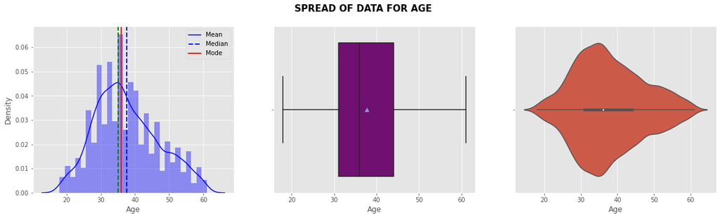

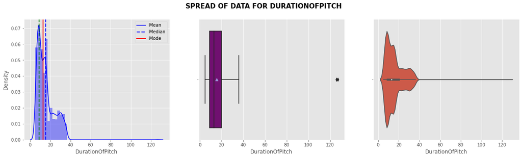

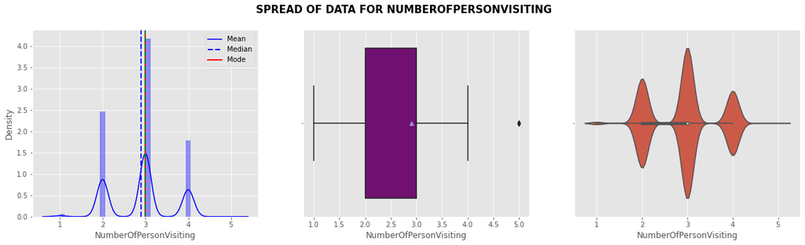

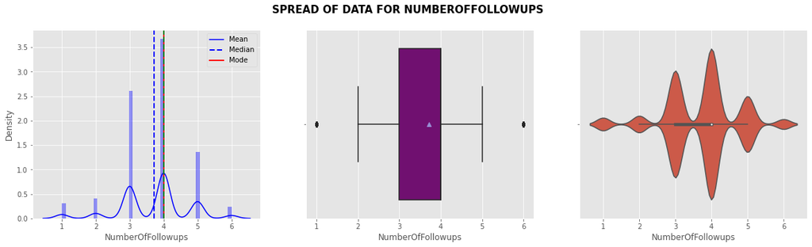

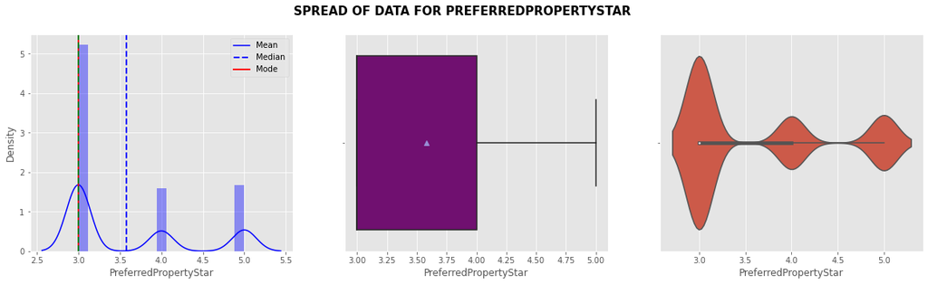

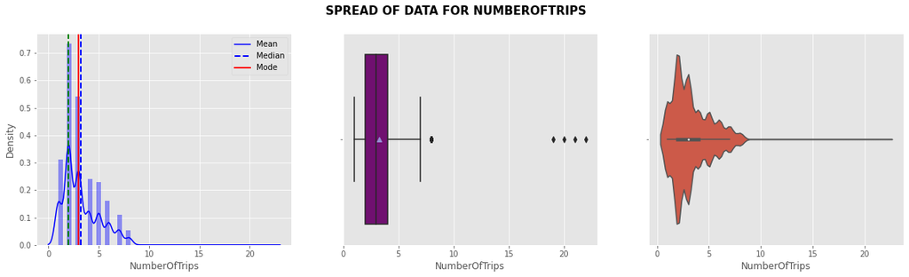

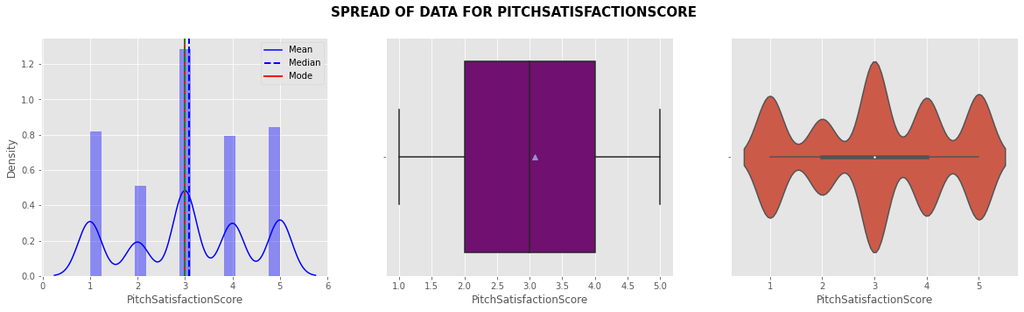

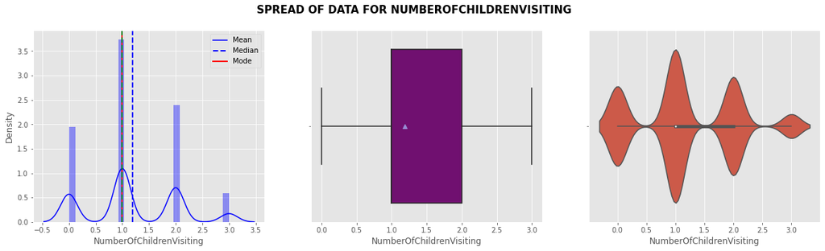

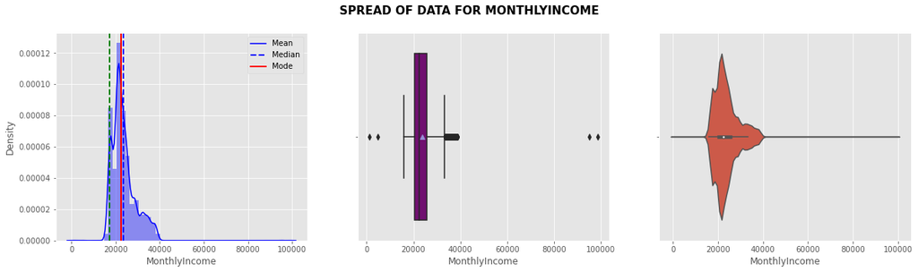

```python
list_col=  data.select_dtypes(include='number').columns.to_list()
for i in range(len(list_col)):
    diff_plots(data[list_col[i]])
```

### Inferences

- Age is normally distrubted and doesn't seem to have any outliers. It has a slightly right skewed data.
- Duration of pitch is heavily right skewed we observe some outliers greater than 120. This might be ther reason for the change in mean(15) vs the median (13).
- Number of visitors is usually 3 and with 2 and 4 sharing the next most frequent numbers. There are some outliers in the data which might need checking.
- We had seen that the mean and median of follow ups tends to 4 and we can see a similar result graphically.
- Number of trips is right skewed with some outliers where trips are greater than 17. But usually the no. of trips is less with an average of 3.
- Monthly income is Right skewed. and has some outlier as higher end.

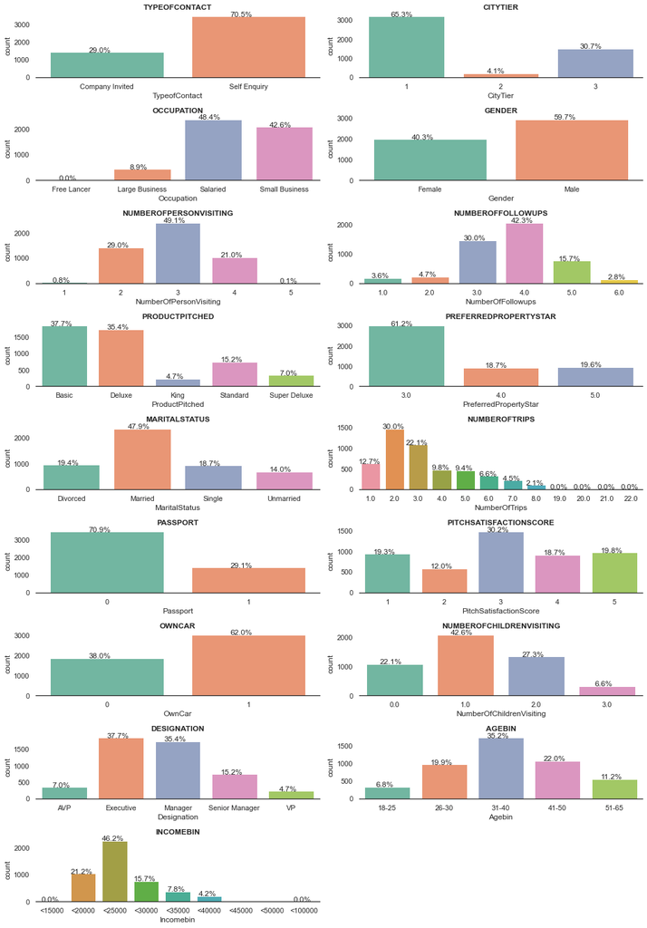

```python
# Ckecking categorical values

plt.figure(figsize=(14,20))

sns.set_theme(style="white")
cols=['TypeofContact', 'CityTier', 'Occupation', 'Gender',
        'NumberOfPersonVisiting', 'NumberOfFollowups', 'ProductPitched',
        'PreferredPropertyStar', 'MaritalStatus', 'NumberOfTrips',
        'Passport', 'PitchSatisfactionScore',
        'OwnCar', 'NumberOfChildrenVisiting',
        'Designation','Agebin','Incomebin']
for i, variable in enumerate(cols):
                     plt.subplot(9,2,i+1)
                     order = data[variable].value_counts(ascending=False).index

                     sns.set_palette('Set2')
                     ax=sns.countplot(x=data[variable], data=data )
                     sns.despine(top=True,right=True,left=True)
                     for p in ax.patches:
                           percentage = '{:.1f}%'.format(100 * p.get_height()/len(data[variable]))
                           x = p.get_x() + p.get_width() / 2 - 0.05
                           y = p.get_y() + p.get_height()
                           plt.annotate(percentage, (x, y),ha='center')
                     plt.tight_layout()
                     plt.title(cols[i].upper(),fontweight='bold')
```

### Inference:

- We observe that 30% customers come with company invitation and 70% come with a self enquiry.
- Most of the people are from Tier 1 (65.3%).
- The highest occupation category is in Salaried (48.4%) followed by small business owners (42.6%).
- 37.7% works in Executive level, followed by 35.4% of Managers and they both come under the Salaried category of Occupation.
- The population has a higher count of males (59.7%).
- In the population most of the people are married (47.9%).
- Surprisingly most of the people do not have a passport (71%).
- Most of them do own a car (62%).
- Most of them are in the age group of 31-40 with 35.2%. Most customer are in 26-50 age range.
- The majority of customers' monthly income is in the region of 20,000 to 25,000. The majority of customers have a monthly salary of between 15,000 and 30,000.

### Bivariate & Multivariate Analysis

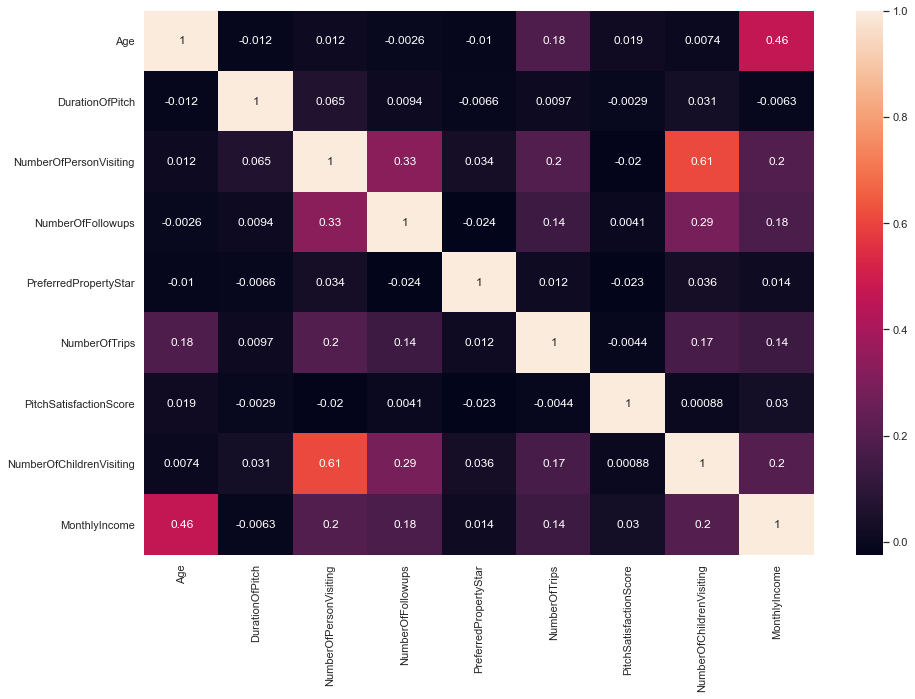

```python
sns.set_palette(sns.color_palette("Set2", 8))
plt.figure(figsize=(15,10))
sns.heatmap(data.corr(),annot=True)
plt.show()
```

### Inference

- Monthlyincome and Age has a 0.46 weak correlation
- Number of children visiting and number of person visiting has a 0.61 which is a stronger relation.
- Numberof follow up and number of person visiting has very weak correlation.

```python
def plot(x,target='ProdTaken'):
    fig,axs = plt.subplots(2,2,figsize=(12,10))
    axs[0, 0].set_title(f'Distribution of {x} \n of a customer who had Not taken Product',fontsize=12,fontweight='bold')
    sns.distplot(data[(data[target] == 0)][x],ax=axs[0,0],color='teal')
    axs[0, 1].set_title(f"Distribution of {x}\n of a customer who had taken Product",fontsize=12,fontweight='bold')
    sns.distplot(data[(data[target] == 1)][x],ax=axs[0,1],color='orange')
    axs[1,0].set_title(f'Boxplot of {x} w.r.t Product taken',fontsize=12,fontweight='bold')

    line = plt.Line2D((.1,.9),(.5,.5), color='grey', linewidth=1.5,linestyle='--')
    fig.add_artist(line)

    sns.boxplot(data[target],data[x],ax=axs[1,0],palette='gist_rainbow',showmeans=True)
    axs[1,1].set_title(f'Boxplot of {x} w.r.t Product Taken - Without outliers',fontsize=12,fontweight='bold')
    sns.boxplot(data[target],data[x],ax=axs[1,1],showfliers=False,palette='gist_rainbow',showmeans=True) #turning off outliers from boxplot
    sns.despine(top=True,right=True,left=True) # to remove side line from graph
    plt.tight_layout(pad=4)
    plt.show()
```

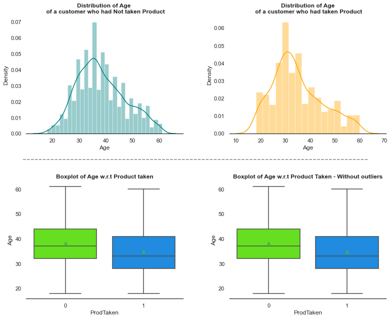

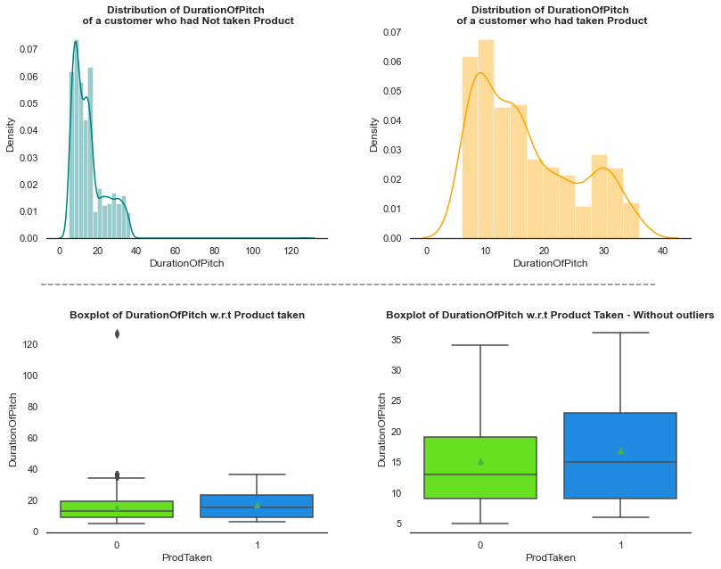

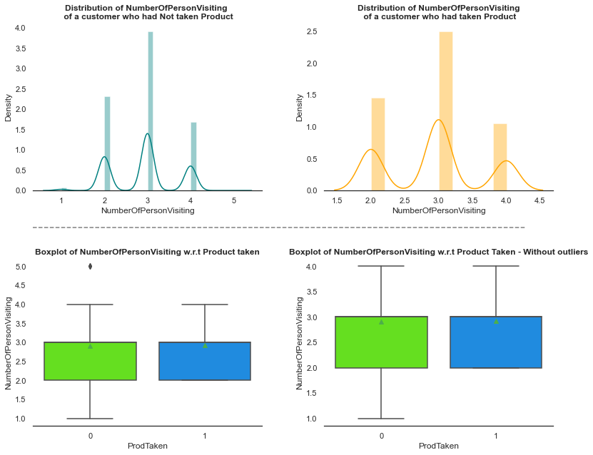

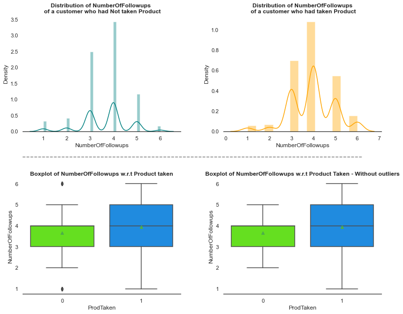

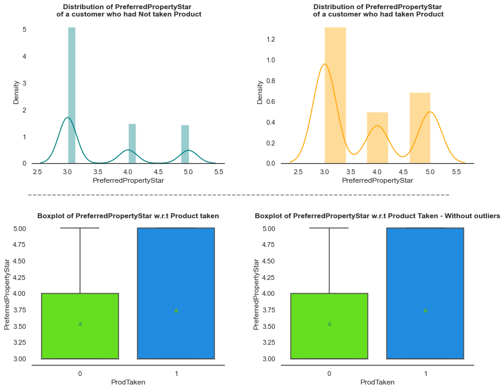

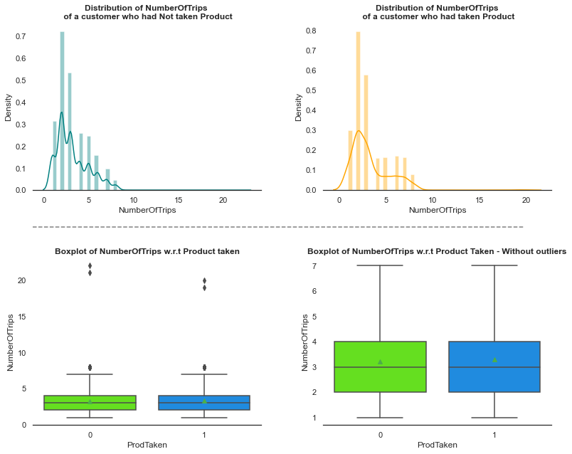

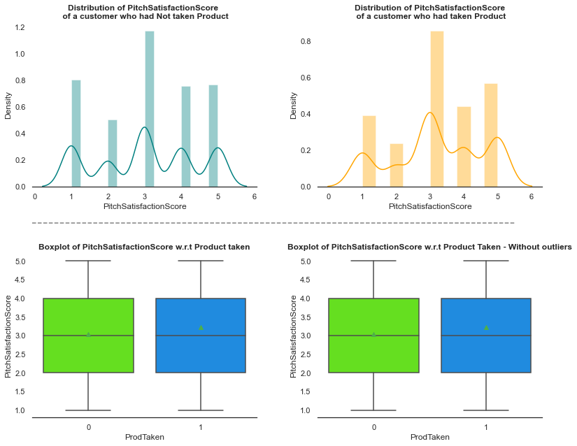

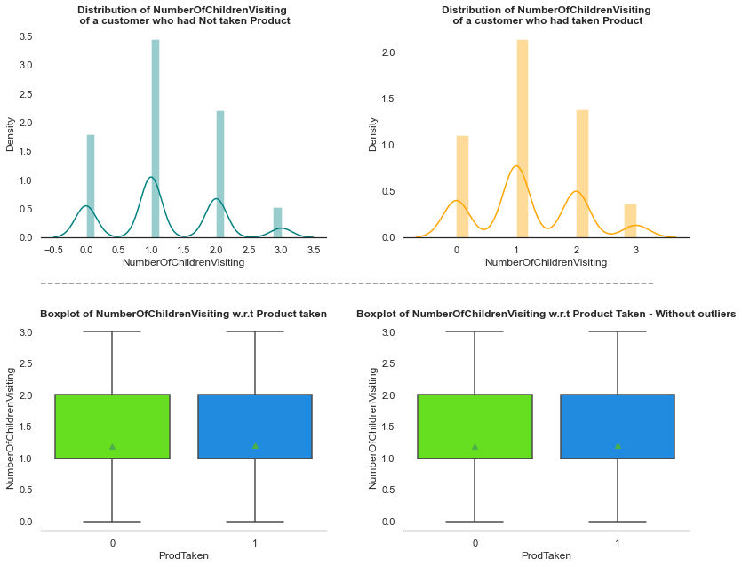

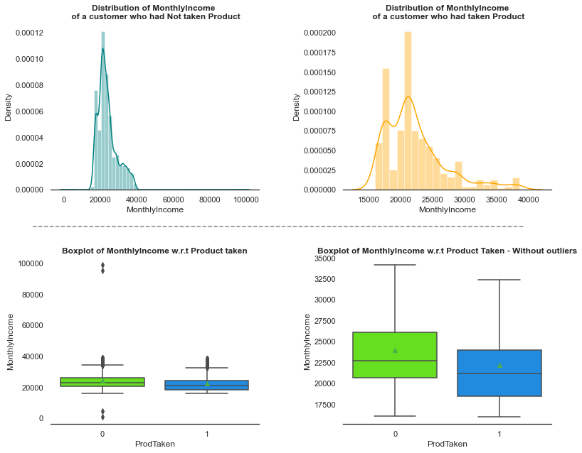

```python
list_col=data.select_dtypes(include='number').columns.to_list()
for j in range(len(list_col)):
   plot(list_col[j])
```

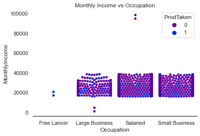

```python
sns.set_palette(sns.color_palette("nipy_spectral", 8))

sns.swarmplot(y='MonthlyIncome',x='Occupation',hue='ProdTaken',data=data)
sns.despine(top=True,right=True,left=True) # to remove side line from graph
plt.title('Monthly Income vs Occupation')
```

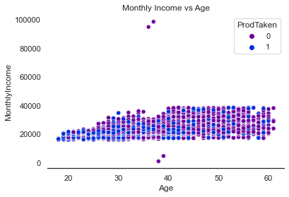

```python
sns.set_palette(sns.color_palette("nipy_spectral", 8))
sns.scatterplot(y='MonthlyIncome',x='Age',hue='ProdTaken',data=data);
sns.despine(top=True,right=True,left=True) # to remove side line from graph
plt.title('Monthly Income vs Age');
```

### Missing value Detection and Treatment

```python
print ("Missing values :\n\n", data.isnull().sum().sort_values(ascending=False))
```

```
Missing values :

 DurationOfPitch             251
Agebin                      240
Incomebin                   233
MonthlyIncome               233
Age                         226
NumberOfTrips               140
NumberOfChildrenVisiting     66
NumberOfFollowups            45
PreferredPropertyStar        26
TypeofContact                25
MaritalStatus                 0
Passport                      0
ProductPitched                0
PitchSatisfactionScore        0
NumberOfPersonVisiting        0
Gender                        0
Occupation                    0
OwnCar                        0
CityTier                      0
Designation                   0
ProdTaken                     0
dtype: int64
```

*Missing value Treatment* **Type of contact**

```python
data['TypeofContact'].value_counts()
```

```
Self Enquiry       3444
Company Invited    1419
Name: TypeofContact, dtype: int64
```

```python
#Since we have most of the values in Self Enquiry, we can fill up the missing values with the mode
data['TypeofContact'].mode()

data['TypeofContact']=data['TypeofContact'].fillna('Self Enquiry')
```

```python
data["TypeofContact"].isnull().sum()
```

```
0
```

*Missing value Treatment* **number of followup**

```python
# filling up number of followup with median

data['NumberOfFollowups']=data.groupby(["Gender",'ProductPitched'])["NumberOfFollowups"].apply(lambda x:x.fillna(x.median()))
```

```python
data["NumberOfFollowups"].isnull().sum()
```

```
0
```

*Missing value Treatment* **PreferredPropertyStar**

```python
# we can fill in preferred propert star in terms with the designation and income
data['PreferredPropertyStar']=data.groupby(["Designation"])["PreferredPropertyStar"].apply(lambda x:x.fillna(x.median()))
data['PreferredPropertyStar']=data.groupby(["MonthlyIncome"])["PreferredPropertyStar"].apply(lambda x:x.fillna(x.median()))
data['PreferredPropertyStar']=data.groupby(["Age"])["PreferredPropertyStar"].apply(lambda x:x.fillna(x.median()))
data['PreferredPropertyStar']=data.groupby(["DurationOfPitch"])["PreferredPropertyStar"].apply(lambda x:x.fillna(x.median()))
data['PreferredPropertyStar']=data.groupby(["NumberOfTrips"])["PreferredPropertyStar"].apply(lambda x:x.fillna(x.median()))
data['PreferredPropertyStar']=data.groupby(["NumberOfFollowups"])["PreferredPropertyStar"].apply(lambda x:x.fillna(x.median()))
```

```python
data["PreferredPropertyStar"].isnull().sum()
```

```
0
```

*Missing value Treatment* **Duration of pitch**

Let see how can we impute Duration of pitch.In my opinion an important factor for how long sale person take times to market his sales pitch depends on Product which sale person is proposing , number of followup will also decide duration of pitch. Let verify this.

```python
data.groupby(['ProductPitched','NumberOfFollowups'], as_index=False)["DurationOfPitch"].median()
```

|  | ProductPitched | NumberOfFollowups | DurationOfPitch |
| --- | --- | --- | --- |
| 0 | Basic | 1.00000 | 14.00000 |
| 1 | Basic | 2.00000 | 15.00000 |
| 2 | Basic | 3.00000 | 13.00000 |
| 3 | Basic | 4.00000 | 13.00000 |
| 4 | Basic | 5.00000 | 12.00000 |
| 5 | Basic | 6.00000 | 15.50000 |
| 6 | Deluxe | 1.00000 | 11.50000 |
| 7 | Deluxe | 2.00000 | 13.00000 |
| 8 | Deluxe | 3.00000 | 14.00000 |
| 9 | Deluxe | 4.00000 | 14.00000 |
| 10 | Deluxe | 5.00000 | 13.00000 |
| 11 | Deluxe | 6.00000 | 13.00000 |
| 12 | King | 1.00000 | 15.00000 |
| 13 | King | 2.00000 | 15.50000 |
| 14 | King | 3.00000 | 10.00000 |
| 15 | King | 4.00000 | 11.00000 |
| 16 | King | 5.00000 | 10.00000 |
| 17 | King | 6.00000 | 9.00000 |
| 18 | Standard | 1.00000 | 14.00000 |
| 19 | Standard | 2.00000 | 15.00000 |
| 20 | Standard | 3.00000 | 14.00000 |
| 21 | Standard | 4.00000 | 14.00000 |
| 22 | Standard | 5.00000 | 14.00000 |
| 23 | Standard | 6.00000 | 14.00000 |
| 24 | Super Deluxe | 1.00000 | 12.50000 |
| 25 | Super Deluxe | 2.00000 | 13.00000 |
| 26 | Super Deluxe | 3.00000 | 13.00000 |
| 27 | Super Deluxe | 4.00000 | 12.50000 |
| 28 | Super Deluxe | 5.00000 | 13.00000 |
| 29 | Super Deluxe | 6.00000 | 16.00000 |

```python
# Filling missing Duration of pitch with median value
data["DurationOfPitch"] = data.groupby(["ProductPitched",'NumberOfFollowups'])["DurationOfPitch"].apply(
    lambda x: x.fillna(x.median()))
```

```python
data["DurationOfPitch"].isnull().sum()
```

```
0
```

*Missing value Treatment* **NumberOfTrips**

```python
#Number of Trips could be similar with married or single people
data.groupby(['MaritalStatus'])["NumberOfTrips"].median()
```

```
MaritalStatus
Divorced    3.00000
Married     3.00000
Single      2.00000
Unmarried   3.00000
Name: NumberOfTrips, dtype: float64
```

```python
# Filling in missing NumberOfTrips of pitch with median value
data["NumberOfTrips"] = data.groupby(["MaritalStatus"])["NumberOfTrips"].apply(
    lambda x: x.fillna(x.median()))
```

```python
data["NumberOfTrips"].isnull().sum()
```

```
0
```

*Missing value Treatment* **NumberOfChildrenVisiting**

```python
# We can assume the number of children visiting could be because there is no children and hence we could fill it up with '0'
data['NumberOfChildrenVisiting']=data['NumberOfChildrenVisiting'].fillna(0)
```

```python
data["NumberOfChildrenVisiting"].isnull().sum()
```

```
0
```

*Missing value Treatment* **Age**

```python
# We can try to fill up the age column with medians with respect to designation, gender and marital status
data.groupby(["Designation", "Gender","MaritalStatus"])["Age"].median()

# Impute missing Age with median value
data["Age"] = data.groupby(["Designation", "Gender","MaritalStatus"])["Age"].apply(
    lambda x: x.fillna(x.median())
)
```

```python
data["Age"].isnull().sum()
```

```
0
```

*Missing value Treatment* **MonthlyIncome**

```python
# We can try to fill up the Monthly Income column with medians with respect to designation, gender and occupation
data.groupby(["Occupation",'Designation','Gender'])["MonthlyIncome"].median()
```

```
Occupation      Designation     Gender
Free Lancer     AVP             Female           nan
                                Male             nan
                Executive       Female           nan
                                Male     18929.00000
                Manager         Female           nan
                                Male             nan
                Senior Manager  Female           nan
                                Male             nan
                VP              Female           nan
                                Male             nan
Large Business  AVP             Female   31872.00000
                                Male     29959.00000
                Executive       Female   20748.00000
                                Male     20743.50000
                Manager         Female   22198.50000
                                Male     21997.00000
                Senior Manager  Female   28266.00000
                                Male     26838.50000
                VP              Female   36583.00000
                                Male     36071.00000
Salaried        AVP             Female   31890.00000
                                Male     32505.50000
                Executive       Female   20748.00000
                                Male     20371.50000
                Manager         Female   22826.00000
                                Male     22873.50000
                Senior Manager  Female   26713.00000
                                Male     26052.50000
                VP              Female   35846.00000
                                Male     35971.00000
Small Business  AVP             Female   32171.50000
                                Male     32386.00000
                Executive       Female   20685.00000
                                Male     20582.00000
                Manager         Female   23071.00000
                                Male     22984.00000
                Senior Manager  Female   26383.50000
                                Male     26297.00000
                VP              Female   34845.00000
                                Male     35868.50000
Name: MonthlyIncome, dtype: float64
```

```python
data["MonthlyIncome"]=data.groupby(["Occupation",'Designation','Gender'])["MonthlyIncome"].apply(
    lambda x: x.fillna(x.median())
)
```

```python
data["MonthlyIncome"].isnull().sum()
```

```
0
```

```python
#Checking for all missing values again!!
data.isnull().sum()
```

```
ProdTaken                     0
Age                           0
TypeofContact                 0
CityTier                      0
DurationOfPitch               0
Occupation                    0
Gender                        0
NumberOfPersonVisiting        0
NumberOfFollowups             0
ProductPitched                0
PreferredPropertyStar         0
MaritalStatus                 0
NumberOfTrips                 0
Passport                      0
PitchSatisfactionScore        0
OwnCar                        0
NumberOfChildrenVisiting      0
Designation                   0
MonthlyIncome                 0
Agebin                      240
Incomebin                   233
dtype: int64
```

We have finally been able to cover up the missing values in the main data. There is still some categories that needs filling, i.e, Agebin and Incomebin

Since our aim is to check the variables/features that affect the business we can look into **Age** and **Income** which we understand from the data given.

```python
data.Age.describe()
```

```
count   4888.00000
mean      37.41356
std        9.16280
min       18.00000
25%       31.00000
50%       36.00000
75%       43.00000
max       61.00000
Name: Age, dtype: float64
```

```python
data['Agebin'] = pd.cut(data['Age'], bins = [15,25, 31, 40, 50, 70], labels = ['15-25','26-30', '31-40', '41-50', '51-70'])
```

```python
data.Agebin.value_counts()
```

```
31-40    1894
41-50    1073
26-30    1025
51-70     549
15-25     347
Name: Agebin, dtype: int64
```

```python
data.MonthlyIncome.describe()
```

```
count    4888.00000
mean    23543.85577
std      5267.65145
min      1000.00000
25%     20438.25000
50%     22393.00000
75%     25424.75000
max     98678.00000
Name: MonthlyIncome, dtype: float64
```

```python
data['Incomebin'] = pd.cut(data['MonthlyIncome'], bins = [0,15000,20000, 25000, 30000,35000,40000,45000,50000,100000], labels = ['<15000', '<20000', '<25000', '<30000','<35000','<40000','<45000','<50000','<100000'])
```

```python
data.Incomebin.value_counts()
```

```
<25000     2490
<20000     1038
<30000      768
<35000      382
<40000      206
<100000       2
<15000        2
<50000        0
<45000        0
Name: Incomebin, dtype: int64
```

```python
data.isnull().sum()
```

```
ProdTaken                   0
Age                         0
TypeofContact               0
CityTier                    0
DurationOfPitch             0
Occupation                  0
Gender                      0
NumberOfPersonVisiting      0
NumberOfFollowups           0
ProductPitched              0
PreferredPropertyStar       0
MaritalStatus               0
NumberOfTrips               0
Passport                    0
PitchSatisfactionScore      0
OwnCar                      0
NumberOfChildrenVisiting    0
Designation                 0
MonthlyIncome               0
Agebin                      0
Incomebin                   0
dtype: int64
```

By this we have filled all missing values in all columns. Now we can start analysing

## Customer Profile by Product Type

```python
# grouping customers who bought the product
cust_prof=data[data['ProdTaken']==1]
```

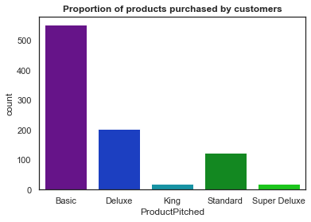

```python
# grouping with respect to the product purchased
sns.countplot(x="ProductPitched", data=cust_prof).set_title('Proportion of products purchased by customers',fontweight="bold");
```

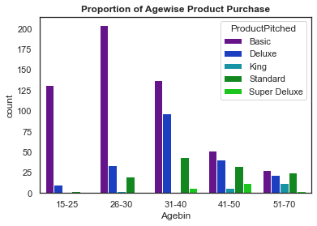

```python
#Agewise grouping of purchase of products
sns.countplot(x='Agebin',hue='ProductPitched',data=cust_prof).set_title('Proportion of Agewise Product Purchase', fontweight="bold");
```

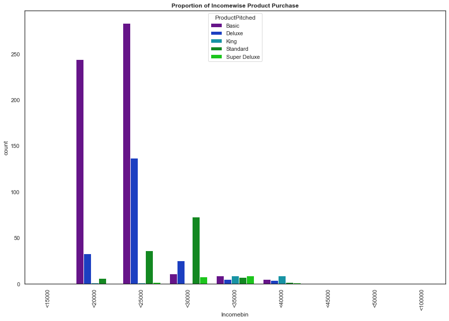

```python
#Incomewise grouping of purchase of products
plt.figure(figsize=(15,10))
sns.countplot(x='Incomebin',hue='ProductPitched',data=cust_prof).set_title('Proportion of Incomewise Product Purchase', fontweight="bold");
plt.xticks(rotation=90);
```

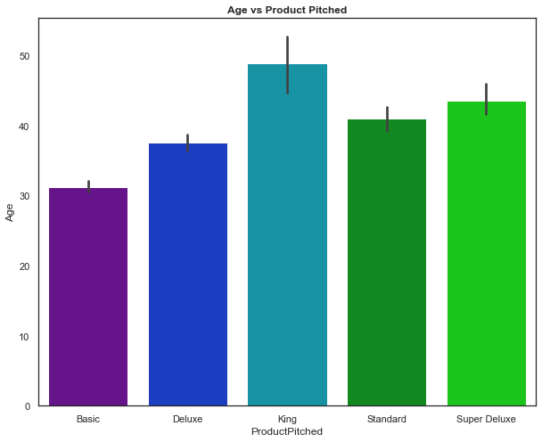

```python
#Understanding category of product purchase in age group
plt.figure(figsize=(10,8))
sns.barplot(y='Age',x='ProductPitched',data=cust_prof).set_title('Age vs Product Pitched',fontweight="bold");
```

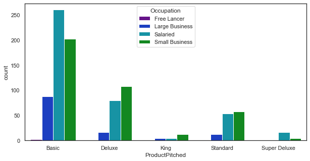

```python
#Understanding category of product purchase with respect to Occupation
plt.figure(figsize=(10,5))
sns.countplot(x="ProductPitched", data=cust_prof,  hue="Occupation");
```

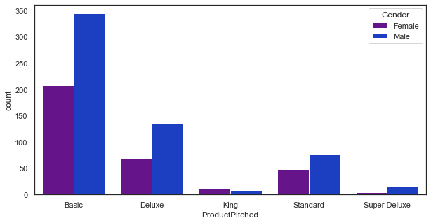

```python
#Understanding category of product purchase with respect to Gender
plt.figure(figsize=(10,5))
sns.countplot(x="ProductPitched", data=cust_prof,  hue="Gender");
```

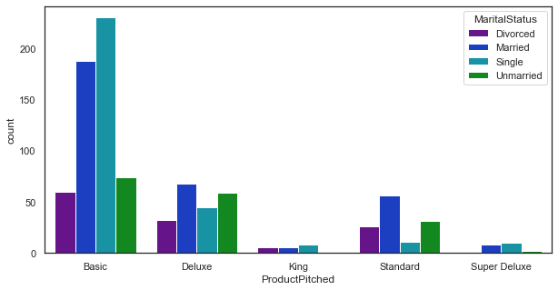

```python
#Understanding category of product purchase with respect to Marital Status
plt.figure(figsize=(10,5))
sns.countplot(x="ProductPitched", data=cust_prof,  hue="MaritalStatus");
```

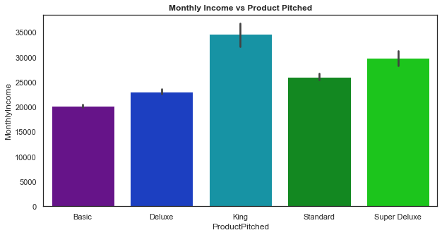

```python
plt.figure(figsize=(10,5))
sns.barplot(y='MonthlyIncome',x='ProductPitched',data=cust_prof).set_title('Monthly Income vs Product Pitched',fontweight="bold");
```

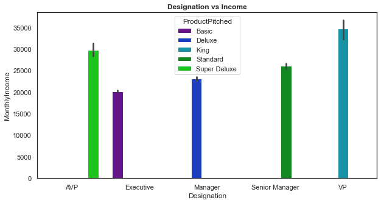

```python
plt.figure(figsize=(10,5))
sns.barplot(x='Designation',y='MonthlyIncome',data=cust_prof,hue='ProductPitched').set_title('Designation vs Income',fontweight="bold");
```